# The time course of injury-risk after return-to-play in professional football (soccer)

Guangze Zhang & Anne Hecksteden

# 1 Read Me

This is an R Markdown document which provides reproducible code for the core analysis in the manuscript, *“The time course of injury-risk after return-to-play in professional football (soccer)”*. This commented code aims only to optimize transparency of the current analysis.

# 2 Survival analysis

## 2.1 Survial function

- Note: Survival function is obtained directly from Kaplan-Meier table.

```r
# Create sobj for all cases
sobj <- Surv(data_analysis$RTP_to_reinjury, data_analysis$Cens)

# Create sobj for severity of index injury
data_minimal <- data_analysis %>% filter(Severity_ini == 1)
sobj_minimal <- Surv(data_minimal$RTP_to_reinjury, data_minimal$Cens)
data_mild <- data_analysis %>% filter(Severity_ini == 2)
sobj_mild <- Surv(data_mild$RTP_to_reinjury, data_mild$Cens)
data_moderate <- data_analysis %>% filter(Severity_ini == 3)
sobj_moderate <- Surv(data_moderate$RTP_to_reinjury, data_moderate$Cens)
data_severe <- data_analysis %>% filter(Severity_ini == 4)
sobj_severe <- Surv(data_severe$RTP_to_reinjury, data_severe$Cens)

# Create sobj for playing position
data_gk <- data_analysis %>% filter(Position == 1)
sobj_gk <- Surv(data_gk$RTP_to_reinjury, data_gk$Cens)
data_def <- data_analysis %>% filter(Position == 2)
sobj_def <- Surv(data_def$RTP_to_reinjury, data_def$Cens)
data_mid <- data_analysis %>% filter(Position == 3)
sobj_mid <- Surv(data_mid$RTP_to_reinjury, data_mid$Cens)
data_fw <- data_analysis %>% filter(Position == 4)
sobj_fw <- Surv(data_fw$RTP_to_reinjury, data_fw$Cens)
```

## 2.2 Cumulative hazard function

- Note: Cumulative hazard function is derived through an established mathematical relationship (negative log) from the survival function.

### 2.2.1 For all non-contact subsequent injuries

```r
km <- survfit(sobj ~ 1)

# Extract information into a data.frame
df_km <- data.frame(time = km$time, n.risk = km$n.risk, n.event = km$n.event,
  n.censor = km$n.censor, surv = km$surv, cumhaz = km$cumhaz)

# Calculate hazard from n.event & n.risk
df_km$hazard_dt <- df_km$n.event / df_km$n.risk

# Calculate cumulative hazard manually
df_km$cumhaz_manual <- -log(df_km$surv)

# Show first rows as an example
head(df_km)
```

```
##   time n.risk n.event n.censor      surv      cumhaz   hazard_dt cumhaz_manual
## 1    1   3179      31       25 0.9902485 0.009751494 0.009751494   0.009799351
## 2    2   3123      44       28 0.9762969 0.023840511 0.014089017   0.023988561
## 3    3   3051      36       23 0.9647772 0.035639921 0.011799410   0.035858136
## 4    4   2992      32       19 0.9544587 0.046335108 0.010695187   0.046610928
## 5    5   2941      32       13 0.9440735 0.057215761 0.010880653   0.057551208
## 6    6   2896      37       17 0.9320118 0.069992004 0.012776243   0.070409769
```

### 2.2.2 Seperate models by the severity of index injury

```r
# For minimal index injuries
km_minimal <- survfit(sobj_minimal ~ 1)

# Extract information into a data.frame
df_km_minimal <- data.frame(time = km_minimal$time, n.risk = km_minimal$n.risk, n.event = km_minimal$n.event,
  n.censor = km_minimal$n.censor, surv = km_minimal$surv, cumhaz = km_minimal$cumhaz)

# Calculate hazard from n.event & n.risk
df_km_minimal$hazard_dt <- df_km_minimal$n.event / df_km_minimal$n.risk

# Calculate cumulative hazard manually
df_km_minimal$cumhaz_manual <- -log(df_km_minimal$surv)
head(df_km_minimal)
```

```
##   time n.risk n.event n.censor      surv     cumhaz  hazard_dt cumhaz_manual
## 1    1   1291      15       14 0.9883811 0.01161890 0.01161890    0.01168693
## 2    2   1262      20       12 0.9727174 0.02746676 0.01584786    0.02766171
## 3    3   1230      19       15 0.9576917 0.04291392 0.01544715    0.04322941
## 4    4   1196      14       10 0.9464812 0.05461960 0.01170569    0.05500415
## 5    5   1172      16        8 0.9335600 0.06827148 0.01365188    0.06875007
## 6    6   1148      16       11 0.9205487 0.08220876 0.01393728    0.08278539
```

```r
# For mild index injuries
km_mild <- survfit(sobj_mild ~ 1)

# Extract information into a data.frame
df_km_mild <- data.frame(time = km_mild$time, n.risk = km_mild$n.risk, n.event = km_mild$n.event,
  n.censor = km_mild$n.censor, surv = km_mild$surv, cumhaz = km_mild$cumhaz)

# Calculate hazard from n.event & n.risk
df_km_mild$hazard_dt <- df_km_mild$n.event / df_km_mild$n.risk

# Calculate cumulative hazard manually
df_km_mild$cumhaz_manual <- -log(df_km_mild$surv)
head(df_km_mild)
```

```
##   time n.risk n.event n.censor      surv      cumhaz   hazard_dt cumhaz_manual
## 1    1    648       5        6 0.9922840 0.007716049 0.007716049   0.007745972
## 2    2    637       9        6 0.9782642 0.021844778 0.014128728   0.021975461
## 3    3    622      11        1 0.9609637 0.039529665 0.017684887   0.039818595
## 4    4    610       8        1 0.9483609 0.052644419 0.013114754   0.053020107
## 5    5    601       5        4 0.9404711 0.060963887 0.008319468   0.061374374
## 6    6    592       7        2 0.9293507 0.072788211 0.011824324   0.073269162
```

```r
# For moderate index injuries
km_moderate <- survfit(sobj_moderate ~ 1)

# Extract information into a data.frame
df_km_moderate <- data.frame(time = km_moderate$time, n.risk = km_moderate$n.risk, n.event = km_moderate$n.event,
  n.censor = km_moderate$n.censor, surv = km_moderate$surv, cumhaz = km_moderate$cumhaz)

# Calculate hazard from n.event & n.risk
df_km_moderate$hazard_dt <- df_km_moderate$n.event / df_km_moderate$n.risk

# Calculate cumulative hazard manually
df_km_moderate$cumhaz_manual <- -log(df_km_moderate$surv)
head(df_km_moderate)
```

```
##   time n.risk n.event n.censor      surv     cumhaz   hazard_dt cumhaz_manual
## 1    1    781       8        2 0.9897567 0.01024328 0.010243278    0.01029610
## 2    2    771      10        8 0.9769194 0.02321345 0.012970169    0.02335112
## 3    3    753       5        4 0.9704326 0.02985355 0.006640106    0.03001337
## 4    4    744       7        5 0.9613021 0.03926215 0.009408602    0.03946651
## 5    5    732       7        1 0.9521094 0.04882500 0.009562842    0.04907537
## 6    6    724       7        4 0.9429039 0.05849350 0.009668508    0.05879092
```

```r
# For severe index injuries
km_severe <- survfit(sobj_severe ~ 1)

# Extract information into a data.frame
df_km_severe <- data.frame(time = km_severe$time, n.risk = km_severe$n.risk, n.event = km_severe$n.event,
  n.censor = km_severe$n.censor, surv = km_severe$surv, cumhaz = km_severe$cumhaz)

# Calculate hazard from n.event & n.risk
df_km_severe$hazard_dt <- df_km_severe$n.event / df_km_severe$n.risk

# Calculate cumulative hazard manually
df_km_severe$cumhaz_manual <- -log(df_km_severe$surv)
head(df_km_severe)
```

```
##   time n.risk n.event n.censor      surv      cumhaz   hazard_dt cumhaz_manual
## 1    1    459       3        3 0.9934641 0.006535948 0.006535948   0.006557401
## 2    2    453       5        2 0.9824987 0.017573475 0.011037528   0.017656294
## 3    3    446       1        3 0.9802958 0.019815628 0.002242152   0.019900963
## 4    4    442       3        3 0.9736422 0.026602958 0.006787330   0.026711432
## 5    5    436       4        0 0.9647097 0.035777270 0.009174312   0.035928088
## 6    6    432       7        0 0.9490778 0.051980974 0.016203704   0.052264507
```

### 2.2.3 Seperate models by the playing position

```r
# For goalkeepers (gk)
km_gk <- survfit(sobj_gk ~ 1)

# Extract information into a data.frame
df_km_gk <- data.frame(time = km_gk$time, n.risk = km_gk$n.risk, n.event = km_gk$n.event,
  n.censor = km_gk$n.censor, surv = km_gk$surv, cumhaz = km_gk$cumhaz)

# Calculate hazard from n.event & n.risk
df_km_gk$hazard_dt <- df_km_gk$n.event / df_km_gk$n.risk

# Calculate cumulative hazard manually
df_km_gk$cumhaz_manual <- -log(df_km_gk$surv)
head(df_km_gk)
```

```
##   time n.risk n.event n.censor      surv     cumhaz   hazard_dt cumhaz_manual
## 1    1    138       3        1 0.9782609 0.02173913 0.021739130    0.02197891
## 2    2    134       3        1 0.9563595 0.04412719 0.022388060    0.04462138
## 3    3    130       1        0 0.9490029 0.05181950 0.007692308    0.05234343
## 4    4    129       1        0 0.9416463 0.05957144 0.007751938    0.06012557
## 5    6    128       1        2 0.9342897 0.06738394 0.007812500    0.06796875
## 6    7    125       2        0 0.9193410 0.08338394 0.016000000    0.08409813
```

```r
# For defenders (def)
km_def <- survfit(sobj_def ~ 1)

# Extract information into a data.frame
df_km_def <- data.frame(time = km_def$time, n.risk = km_def$n.risk, n.event = km_def$n.event,
  n.censor = km_def$n.censor, surv = km_def$surv, cumhaz = km_def$cumhaz)

# Calculate hazard from n.event & n.risk
df_km_def$hazard_dt <- df_km_def$n.event / df_km_def$n.risk

# Calculate cumulative hazard manually
df_km_def$cumhaz_manual <- -log(df_km_def$surv)
head(df_km_def)
```

```
##   time n.risk n.event n.censor      surv      cumhaz   hazard_dt cumhaz_manual
## 1    1   1057      10        8 0.9905393 0.009460738 0.009460738   0.009505775
## 2    2   1039      16       15 0.9752855 0.024860160 0.015399423   0.025025000
## 3    3   1008      11       10 0.9646425 0.035772859 0.010912698   0.035997679
## 4    4    987      14        3 0.9509597 0.049957256 0.014184397   0.050283636
## 5    5    970      12        3 0.9391952 0.062328390 0.012371134   0.062731930
## 6    6    955      13        5 0.9264104 0.075940956 0.013612565   0.076437995
```

```r
# For midfielders (mid)
km_mid <- survfit(sobj_mid ~ 1)

# Extract information into a data.frame
df_km_mid <- data.frame(time = km_mid$time, n.risk = km_mid$n.risk, n.event = km_mid$n.event,
  n.censor = km_mid$n.censor, surv = km_mid$surv, cumhaz = km_mid$cumhaz)

# Calculate hazard from n.event & n.risk
df_km_mid$hazard_dt <- df_km_mid$n.event / df_km_mid$n.risk

# Calculate cumulative hazard manually
df_km_mid$cumhaz_manual <- -log(df_km_mid$surv)
head(df_km_mid)
```

```
##   time n.risk n.event n.censor      surv     cumhaz   hazard_dt cumhaz_manual
## 1    1   1419      12       13 0.9915433 0.00845666 0.008456660    0.00849262
## 2    2   1394      17        8 0.9794513 0.02065178 0.012195122    0.02076271
## 3    3   1369      16        8 0.9680041 0.03233914 0.011687363    0.03251891
## 4    4   1345      15       12 0.9572086 0.04349156 0.011152416    0.04373398
## 5    5   1318      12        9 0.9484935 0.05259627 0.009104704    0.05288039
## 6    6   1297      19        6 0.9345988 0.06724546 0.014649190    0.06763794
```

```r
# For forwards (fw)
km_fw <- survfit(sobj_fw ~ 1)

# Extract information into a data.frame
df_km_fw <- data.frame(time = km_fw$time, n.risk = km_fw$n.risk, n.event = km_fw$n.event,
  n.censor = km_fw$n.censor, surv = km_fw$surv, cumhaz = km_fw$cumhaz)

# Calculate hazard from n.event & n.risk
df_km_fw$hazard_dt <- df_km_fw$n.event / df_km_fw$n.risk

# Calculate cumulative hazard manually
df_km_fw$cumhaz_manual <- -log(df_km_fw$surv)
head(df_km_fw)
```

```
##   time n.risk n.event n.censor      surv     cumhaz   hazard_dt cumhaz_manual
## 1    1    565       6        3 0.9893805 0.01061947 0.010619469    0.01067626
## 2    2    556       8        4 0.9751448 0.02500796 0.014388489    0.02516927
## 3    3    544       8        5 0.9608045 0.03971384 0.014705882    0.03998435
## 4    4    531       2        4 0.9571856 0.04348032 0.003766478    0.04375794
## 5    5    525       8        1 0.9425999 0.05871841 0.015238095    0.05911333
## 6    6    516       4        4 0.9352930 0.06647035 0.007751938    0.06689547
```

## 2.3 Visualize survival function & cumulative hazard function

- Note: Given that survival function is not used for further analysis, only the global survival function is provided here to illustrate the analytical pipeline.

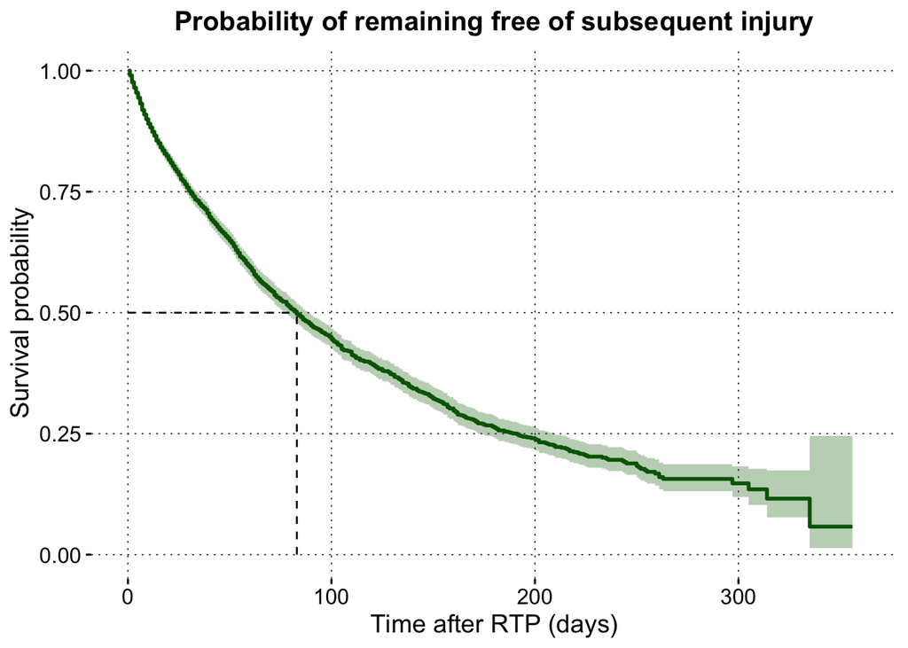

```r
# Survival function
survprobplot <- ggsurvplot(surv_fit(sobj ~ 1, data = data_analysis), risk.table = TRUE, surv.median.line = "hv", censor=FALSE, legend = "none", palette= 'darkgreen', xlim = c(0, 360))
survprobplot$plot + labs(title = "Probability of remaining free of subsequent injury", x = "Time after RTP (days)", y = "Survival probability") + xlim(0,360) + theme(plot.title = element_text(face="bold", hjust= .5, size = 15), panel.background = element_rect(fill = "white"), panel.grid.major = element_line(color = "gray10", size = .3, linetype = "dotted"), axis.line=element_line (colour = "transparent")) + guides(color = guide_legend(direction = "horizontal"))
```

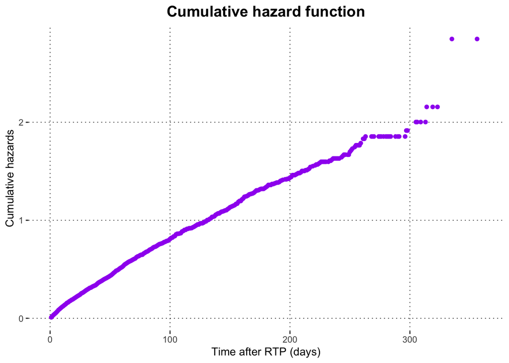

```r
# Plot manually calculated cumulative hazards from Kaplan-Meier table
ggplot(NULL)+geom_point(data=df_km, aes(x=time, y=cumhaz_manual), col="purple") + labs(title = "Cumulative hazard function", x = "Time after RTP (days)", y = "Cumulative hazards") + xlim(0,360) + theme(plot.title = element_text(face="bold", hjust= .5, size = 15), panel.background = element_rect(fill = "white"), panel.grid.major = element_line(color = "gray10", size = .3, linetype = "dotted"), axis.line=element_line (colour = "transparent")) + guides(color = guide_legend(direction = "horizontal"))
```

# 3 Continuous cumulative hazard function

## 3.1 Fit a polynomial to the cumulative hazard function from Kaplan-Meier model

- Note: Polynomial regression here is used to fit the stair-step cumulative hazard function, producing a smooth fine-grained curve which is subsequently used to calculate daily hazards as the rate of change (local slope) in cumulative hazard function.

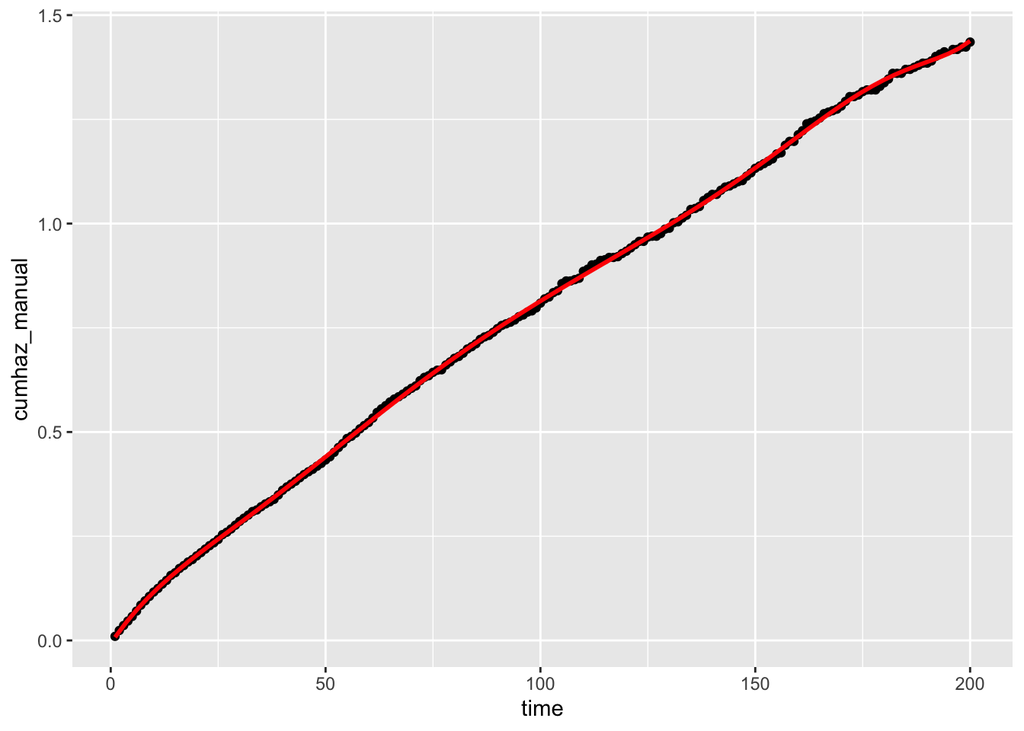

```r
# all non-contact subsequent injuries
df_km_200 <- filter(df_km, time <= 200)
Cumhaz_mod <- lm(df_km_200$cumhaz_manual ~ poly(df_km_200$time, 10, raw=TRUE))
## Check if 10rd-degree polynomial could fit cumulative hazard well
ggplot(df_km_200, aes(x=time, y=cumhaz_manual)) + geom_point() + stat_smooth(method="lm", se=FALSE, fill=NA,
                formula=y ~ poly(x, 10, raw=TRUE),colour="red")
```

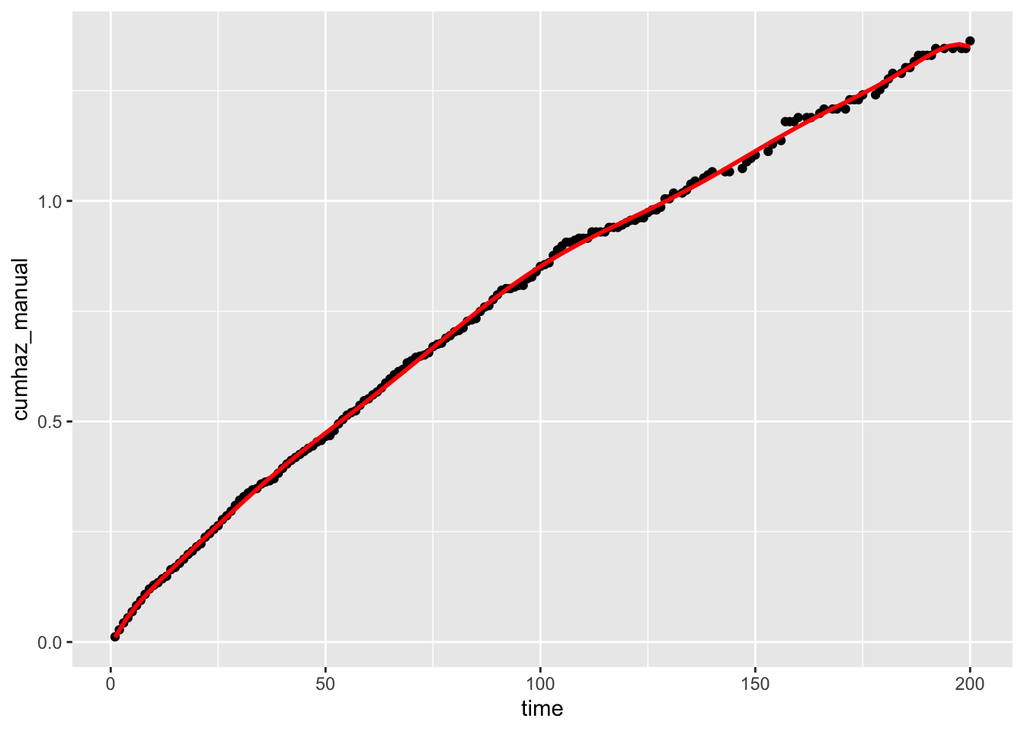

```r
# minimal
df_km_200_minimal <- filter(df_km_minimal, time <= 200)
Cumhaz_mod_minimal <- lm(df_km_200_minimal$cumhaz_manual ~ poly(df_km_200_minimal$time, 10, raw=TRUE))
## Check if 10rd-degree polynomial could fit cumulative hazard well
ggplot(df_km_200_minimal, aes(x=time, y=cumhaz_manual)) + geom_point() + stat_smooth(method="lm", se=FALSE, fill=NA,
                formula=y ~ poly(x, 10, raw=TRUE),colour="red")
```

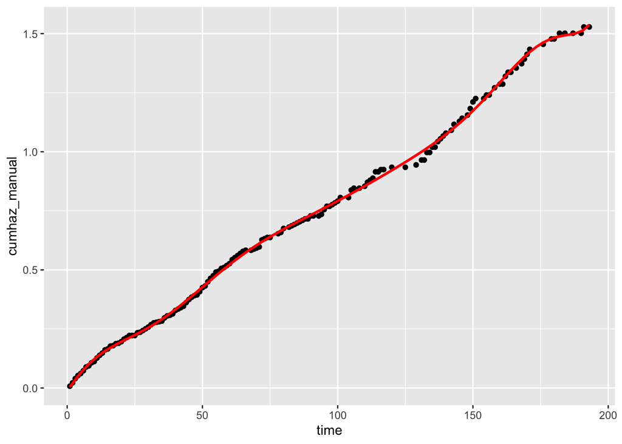

```r
# mild
df_km_200_mild <- filter(df_km_mild, time <= 200)
Cumhaz_mod_mild <- lm(df_km_200_mild$cumhaz_manual ~ poly(df_km_200_mild$time, 10, raw=TRUE))
## Check if 10rd-degree polynomial could fit cumulative hazard well
ggplot(df_km_200_mild, aes(x=time, y=cumhaz_manual)) + geom_point() + stat_smooth(method="lm", se=FALSE, fill=NA,
                formula=y ~ poly(x, 10, raw=TRUE),colour="red")
```

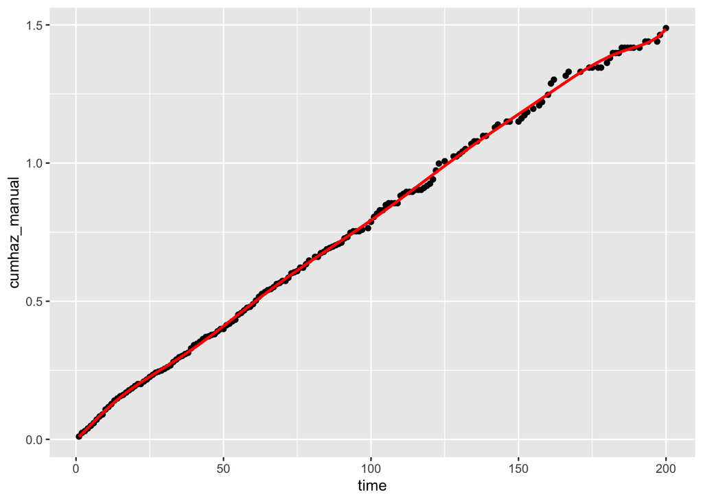

```r
# moderate
df_km_200_moderate <- filter(df_km_moderate, time <= 200)
Cumhaz_mod_moderate <- lm(df_km_200_moderate$cumhaz_manual ~ poly(df_km_200_moderate$time, 10, raw=TRUE))
## Check if 10rd-degree polynomial could fit cumulative hazard well
ggplot(df_km_200_moderate, aes(x=time, y=cumhaz_manual)) + geom_point() + stat_smooth(method="lm", se=FALSE, fill=NA,
                formula=y ~ poly(x, 10, raw=TRUE),colour="red")
```

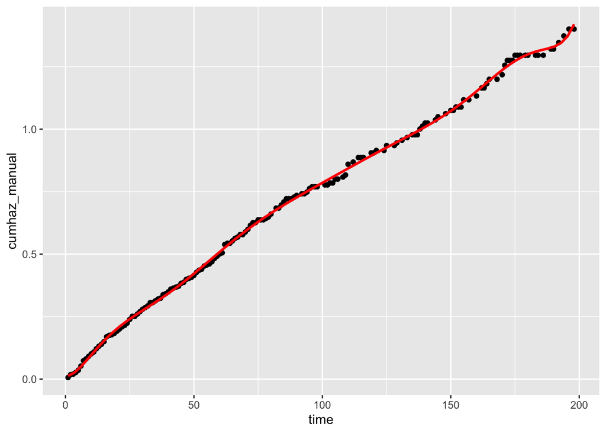

```r
# severe
df_km_200_severe <- filter(df_km_severe, time <= 200)
Cumhaz_mod_severe <- lm(df_km_200_severe$cumhaz_manual ~ poly(df_km_200_severe$time, 10, raw=TRUE))
## Check if 10rd-degree polynomial could fit cumulative hazard well
ggplot(df_km_200_severe, aes(x=time, y=cumhaz_manual)) + geom_point() + stat_smooth(method="lm", se=FALSE, fill=NA,
                formula=y ~ poly(x, 10, raw=TRUE),colour="red")
```

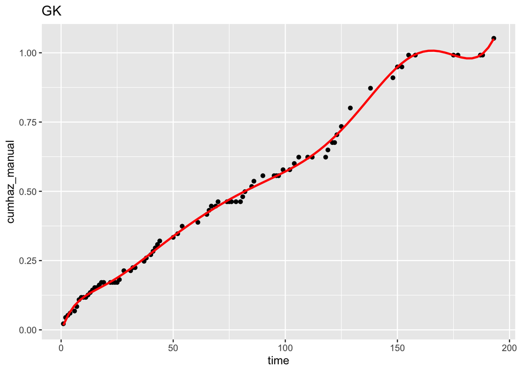

```r
# GK
df_km_200_gk <- filter(df_km_gk, time <= 200) # why choosing 200 here?
Cumhaz_mod_gk <- lm(df_km_200_gk$cumhaz_manual ~ poly(df_km_200_gk$time, 10, raw=TRUE))
## Check if 10rd-degree polynomial could fit cumulative hazard well
ggplot(df_km_200_gk, aes(x=time, y=cumhaz_manual)) + geom_point() + stat_smooth(method="lm", se=FALSE, fill=NA,
                formula=y ~ poly(x, 10, raw=TRUE),colour="red") + labs(title="GK")
```

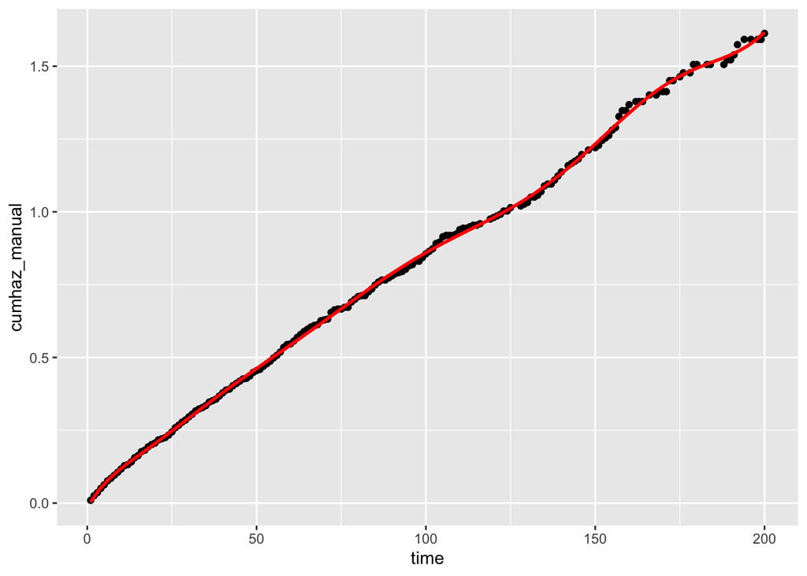

```r
# DEF
df_km_200_def <- filter(df_km_def, time <= 200) # why choosing 200 here?
Cumhaz_mod_def <- lm(df_km_200_def$cumhaz_manual ~ poly(df_km_200_def$time, 10, raw=TRUE))
## check if 10rd-degree polynomial could fit cumulative hazard well
ggplot(df_km_200_def, aes(x=time, y=cumhaz_manual)) + geom_point() + stat_smooth(method="lm", se=FALSE, fill=NA,
                formula=y ~ poly(x, 10, raw=TRUE),colour="red")
```

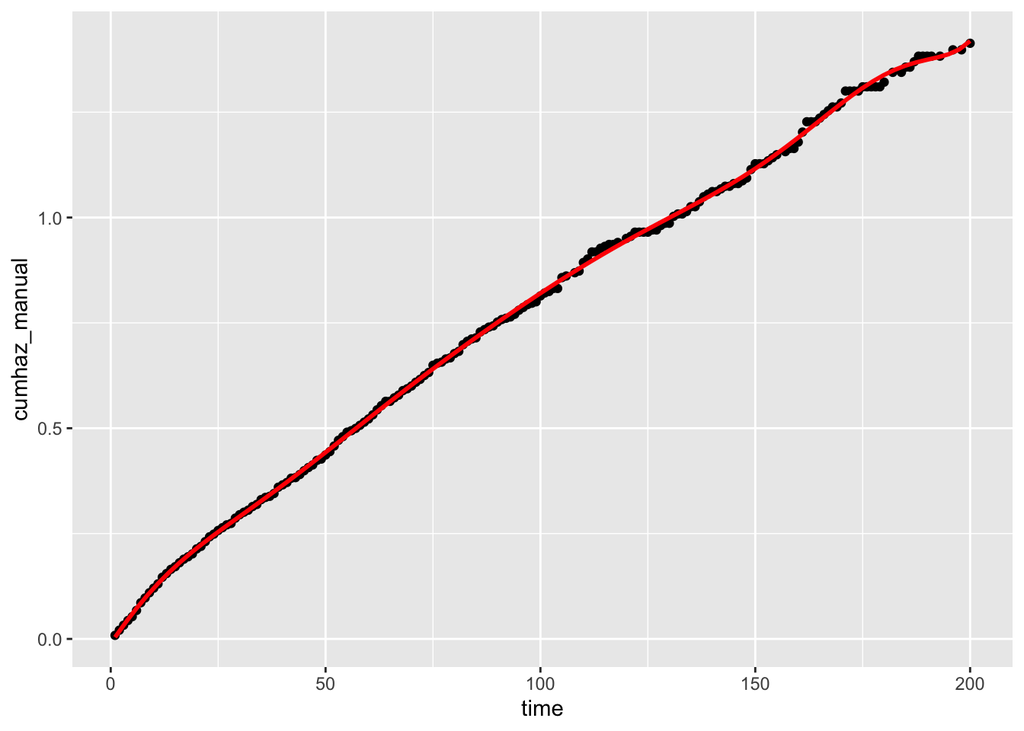

```r
# MID
df_km_200_mid <- filter(df_km_mid, time <= 200) # why choosing 200 here?
Cumhaz_mod_mid <- lm(df_km_200_mid$cumhaz_manual ~ poly(df_km_200_mid$time, 10, raw=TRUE))
## Check if 10rd-degree polynomial could fit cumulative hazard well
ggplot(df_km_200_mid, aes(x=time, y=cumhaz_manual)) + geom_point() + stat_smooth(method="lm", se=FALSE, fill=NA,
                formula=y ~ poly(x, 10, raw=TRUE),colour="red")
```

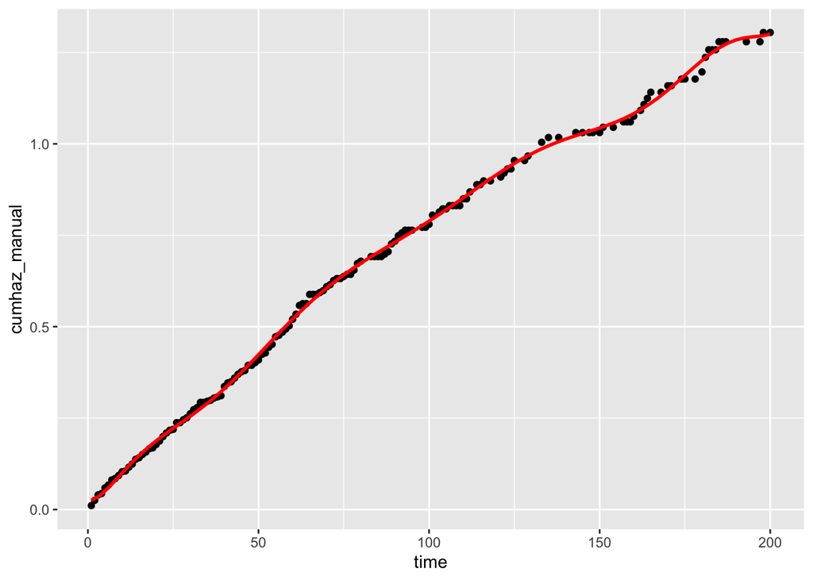

```r
# FW
df_km_200_fw <- filter(df_km_fw, time <= 200) # why choosing 200 here?
Cumhaz_mod_fw <- lm(df_km_200_fw$cumhaz_manual ~ poly(df_km_200_fw$time, 10, raw=TRUE))
## Check if 10rd-degree polynomial could fit cumulative hazard well
ggplot(df_km_200_fw, aes(x=time, y=cumhaz_manual)) + geom_point() + stat_smooth(method="lm", se=FALSE, fill=NA,
                formula=y ~ poly(x, 10, raw=TRUE),colour="red")
```

## 3.2 Make predictions to get a smooth curve of cumulative hazrds over time

```r
# all
Cumhaz_pred <- predict.lm(Cumhaz_mod, newdata = df_km_200, se.fit = TRUE)
Cumhaz_pred_df <- data.frame(Cumhaz_pred = Cumhaz_pred$fit, time = df_km_200$time )

# minimal
Cumhaz_pred_minimal <- predict.lm(Cumhaz_mod_minimal, newdata = df_km_200_minimal, se.fit = TRUE)
Cumhaz_pred_df_minimal <- data.frame(Cumhaz_pred = Cumhaz_pred_minimal$fit, time = df_km_200_minimal$time)

# mild
Cumhaz_pred_mild <- predict.lm(Cumhaz_mod_mild, newdata = df_km_200_mild, se.fit = TRUE)
Cumhaz_pred_df_mild <- data.frame(Cumhaz_pred = Cumhaz_pred_mild$fit, time = df_km_200_mild$time)

# moderate
Cumhaz_pred_moderate <- predict.lm(Cumhaz_mod_moderate, newdata = df_km_200_moderate, se.fit = TRUE)
Cumhaz_pred_df_moderate <- data.frame(Cumhaz_pred = Cumhaz_pred_moderate$fit, time = df_km_200_moderate$time)

# severe
Cumhaz_pred_severe <- predict.lm(Cumhaz_mod_severe, newdata = df_km_200_severe, se.fit = TRUE)
Cumhaz_pred_df_severe <- data.frame(Cumhaz_pred = Cumhaz_pred_severe$fit, time = df_km_200_severe$time)

# GK
Cumhaz_pred_gk <- predict.lm(Cumhaz_mod_gk, newdata = df_km_200_gk, se.fit = TRUE)
Cumhaz_pred_df_gk <- data.frame(Cumhaz_pred = Cumhaz_pred_gk$fit, time = df_km_200_gk$time)

# DEF
Cumhaz_pred_def <- predict.lm(Cumhaz_mod_def, newdata = df_km_200_def, se.fit = TRUE)
Cumhaz_pred_df_def <- data.frame(Cumhaz_pred = Cumhaz_pred_def$fit, time = df_km_200_def$time)

# MID
Cumhaz_pred_mid <- predict.lm(Cumhaz_mod_mid, newdata = df_km_200_mid, se.fit = TRUE)
Cumhaz_pred_df_mid <- data.frame(Cumhaz_pred = Cumhaz_pred_mid$fit, time = df_km_200_mid$time)

# FW
Cumhaz_pred_fw <- predict.lm(Cumhaz_mod_fw, newdata = df_km_200_fw, se.fit = TRUE)
Cumhaz_pred_df_fw <- data.frame(Cumhaz_pred = Cumhaz_pred_fw$fit, time = df_km_200_fw$time)
```

# 4 Compute the local slope of the continuous cumulative hazard function as continuous hazard function

- Note: The local slope of cumulative hazard function represents the day-by-day change, i.e., the daily hazard (or instantaneous risk).

```r
# all
Cumhaz_pred_df_next <- rbind(Cumhaz_pred_df[-1,], c(NA,NA))
Cumhaz_pred_df_next <- Cumhaz_pred_df_next %>%
  dplyr::rename ("Cumhaz_pred_next"="Cumhaz_pred",
                 "time_next"="time"
                 )
Cumhaz_slope <- cbind(Cumhaz_pred_df,Cumhaz_pred_df_next)
# slope(x0) = (y1-y0)/(x1-x0)
Cumhaz_slope$Haz_slope <- (Cumhaz_slope$Cumhaz_pred_next - Cumhaz_slope$Cumhaz_pred)/ (Cumhaz_slope$time_next - Cumhaz_slope$time)
# Show first rows as an example
head(Cumhaz_slope)
```

```
##   Cumhaz_pred time Cumhaz_pred_next time_next  Haz_slope
## 1 0.007671492    1       0.02182999         2 0.01415849
## 2 0.021829985    2       0.03537681         3 0.01354683
## 3 0.035376815    3       0.04834709         4 0.01297028
## 4 0.048347092    4       0.06077590         5 0.01242881
## 5 0.060775898    5       0.07269808         6 0.01192218
## 6 0.072698075    6       0.08414803         7 0.01144996
```

```r
# minimal
Cumhaz_pred_df_minimal_next <- rbind(Cumhaz_pred_df_minimal[-1,], c(NA,NA))
Cumhaz_pred_df_minimal_next <- Cumhaz_pred_df_minimal_next %>%
  dplyr::rename ("Cumhaz_pred_next"="Cumhaz_pred",
                 "time_next"="time"
                 )
Cumhaz_slope_minimal <- cbind(Cumhaz_pred_df_minimal,Cumhaz_pred_df_minimal_next)
# slope(x0) = (y1-y0)/(x1-x0)
Cumhaz_slope_minimal$Haz_slope <- (Cumhaz_slope_minimal$Cumhaz_pred_next - Cumhaz_slope_minimal$Cumhaz_pred)/ (Cumhaz_slope_minimal$time_next - Cumhaz_slope_minimal$time)

# mild
Cumhaz_pred_df_mild_next <- rbind(Cumhaz_pred_df_mild[-1,], c(NA,NA))
Cumhaz_pred_df_mild_next <- Cumhaz_pred_df_mild_next %>%
  dplyr::rename ("Cumhaz_pred_next"="Cumhaz_pred",
                 "time_next"="time"
                 )
Cumhaz_slope_mild <- cbind(Cumhaz_pred_df_mild,Cumhaz_pred_df_mild_next)
# slope(x0) = (y1-y0)/(x1-x0)
Cumhaz_slope_mild$Haz_slope <- (Cumhaz_slope_mild$Cumhaz_pred_next - Cumhaz_slope_mild$Cumhaz_pred)/ (Cumhaz_slope_mild$time_next - Cumhaz_slope_mild$time)

# moderate
Cumhaz_pred_df_moderate_next <- rbind(Cumhaz_pred_df_moderate[-1,], c(NA,NA))
Cumhaz_pred_df_moderate_next <- Cumhaz_pred_df_moderate_next %>%
  dplyr::rename ("Cumhaz_pred_next"="Cumhaz_pred",
                 "time_next"="time"
                 )
Cumhaz_slope_moderate <- cbind(Cumhaz_pred_df_moderate,Cumhaz_pred_df_moderate_next)
# slope(x0) = (y1-y0)/(x1-x0)
Cumhaz_slope_moderate$Haz_slope <- (Cumhaz_slope_moderate$Cumhaz_pred_next - Cumhaz_slope_moderate$Cumhaz_pred)/ (Cumhaz_slope_moderate$time_next - Cumhaz_slope_moderate$time)

# severe
Cumhaz_pred_df_severe_next <- rbind(Cumhaz_pred_df_severe[-1,], c(NA,NA))
Cumhaz_pred_df_severe_next <- Cumhaz_pred_df_severe_next %>%
  dplyr::rename ("Cumhaz_pred_next"="Cumhaz_pred",
                 "time_next"="time"
                 )
Cumhaz_slope_severe <- cbind(Cumhaz_pred_df_severe,Cumhaz_pred_df_severe_next)
# slope(x0) = (y1-y0)/(x1-x0)
Cumhaz_slope_severe$Haz_slope <- (Cumhaz_slope_severe$Cumhaz_pred_next - Cumhaz_slope_severe$Cumhaz_pred)/ (Cumhaz_slope_severe$time_next - Cumhaz_slope_severe$time)

# GK
Cumhaz_pred_df_gk_next <- rbind(Cumhaz_pred_df_gk[-1,], c(NA,NA))
Cumhaz_pred_df_gk_next <- Cumhaz_pred_df_gk_next %>%
  dplyr::rename ("Cumhaz_pred_next"="Cumhaz_pred",
                 "time_next"="time"
                 )
Cumhaz_slope_gk <- cbind(Cumhaz_pred_df_gk,Cumhaz_pred_df_gk_next)
# slope(x0) = (y1-y0)/(x1-x0)
Cumhaz_slope_gk$Haz_slope <- (Cumhaz_slope_gk$Cumhaz_pred_next - Cumhaz_slope_gk$Cumhaz_pred)/ (Cumhaz_slope_gk$time_next - Cumhaz_slope_gk$time)

# MID
Cumhaz_pred_df_mid_next <- rbind(Cumhaz_pred_df_mid[-1,], c(NA,NA))
Cumhaz_pred_df_mid_next <- Cumhaz_pred_df_mid_next %>%
  dplyr::rename ("Cumhaz_pred_next"="Cumhaz_pred",
                 "time_next"="time"
                 )
Cumhaz_slope_mid <- cbind(Cumhaz_pred_df_mid,Cumhaz_pred_df_mid_next)
# slope(x0) = (y1-y0)/(x1-x0)
Cumhaz_slope_mid$Haz_slope <- (Cumhaz_slope_mid$Cumhaz_pred_next - Cumhaz_slope_mid$Cumhaz_pred)/ (Cumhaz_slope_mid$time_next - Cumhaz_slope_mid$time)

# DEF
Cumhaz_pred_df_def_next <- rbind(Cumhaz_pred_df_def[-1,], c(NA,NA))
Cumhaz_pred_df_def_next <- Cumhaz_pred_df_def_next %>%
  dplyr::rename ("Cumhaz_pred_next"="Cumhaz_pred",
                 "time_next"="time"
                 )
Cumhaz_slope_def <- cbind(Cumhaz_pred_df_def,Cumhaz_pred_df_def_next)
# slope(x0) = (y1-y0)/(x1-x0)
Cumhaz_slope_def$Haz_slope <- (Cumhaz_slope_def$Cumhaz_pred_next - Cumhaz_slope_def$Cumhaz_pred)/ (Cumhaz_slope_def$time_next - Cumhaz_slope_def$time)

# FW
Cumhaz_pred_df_fw_next <- rbind(Cumhaz_pred_df_fw[-1,], c(NA,NA))
Cumhaz_pred_df_fw_next <- Cumhaz_pred_df_fw_next %>%
  dplyr::rename ("Cumhaz_pred_next"="Cumhaz_pred",
                 "time_next"="time"
                 )
Cumhaz_slope_fw <- cbind(Cumhaz_pred_df_fw,Cumhaz_pred_df_fw_next)
# slope(x0) = (y1-y0)/(x1-x0)
Cumhaz_slope_fw$Haz_slope <- (Cumhaz_slope_fw$Cumhaz_pred_next - Cumhaz_slope_fw$Cumhaz_pred)/ (Cumhaz_slope_fw$time_next - Cumhaz_slope_fw$time)
```

# 5 Visualize the continuous hazard function

## 5.1 Plot hazard curves

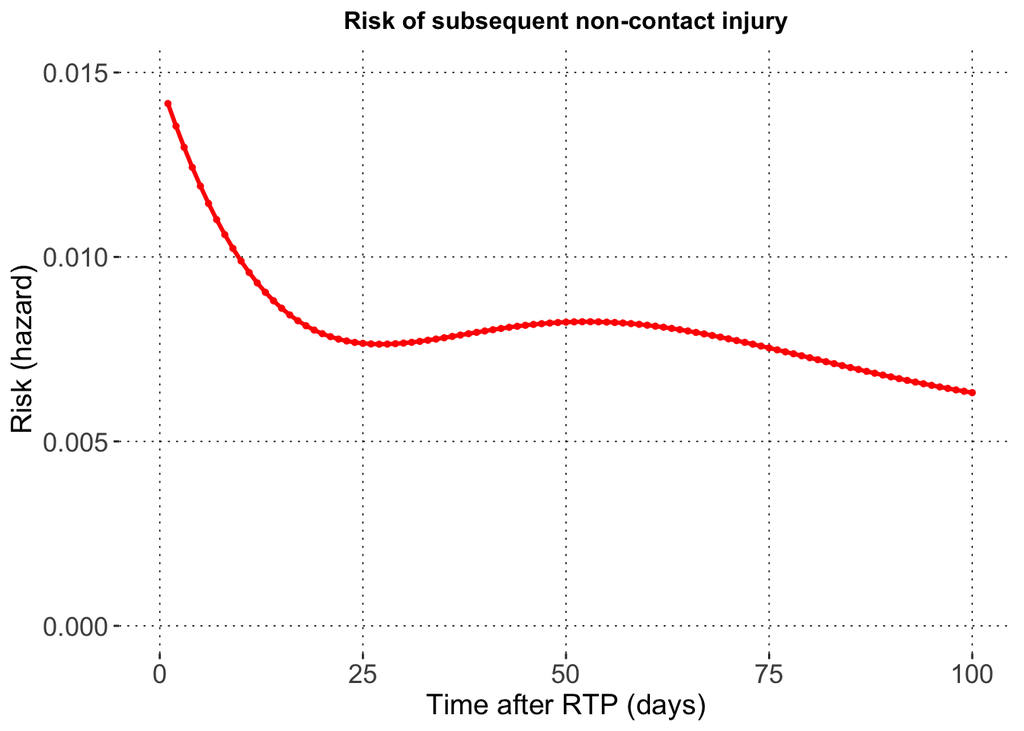

```r
# Create Dataframe for hazards across severities
Cumhaz_slope$Severity <- "Overall"
Cumhaz_slope_minimal$Severity <- "Minimal"
Cumhaz_slope_mild$Severity <- "Mild"
Cumhaz_slope_moderate$Severity <- "Moderate"
Cumhaz_slope_severe$Severity <- "Severe"
Haz_all_seve <- rbind(Cumhaz_slope[,c("time", "Haz_slope", "Severity")], Cumhaz_slope_minimal[,c("time", "Haz_slope", "Severity")], Cumhaz_slope_mild[,c("time", "Haz_slope", "Severity")], Cumhaz_slope_moderate[,c("time", "Haz_slope", "Severity")], Cumhaz_slope_severe[,c("time", "Haz_slope", "Severity")])

# Create Dataframe for hazards across playing positions
Cumhaz_slope$Position <- "Overall"
Cumhaz_slope_gk$Position <- "Goalkeeper"
Cumhaz_slope_def$Position <- "Defender"
Cumhaz_slope_mid$Position <- "Midfielder"
Cumhaz_slope_fw$Position <- "Forward"
Haz_all_pos <- rbind(Cumhaz_slope[,c("time", "Haz_slope", "Position")], Cumhaz_slope_gk[,c("time", "Haz_slope", "Position")], Cumhaz_slope_def[,c("time", "Haz_slope", "Position")], Cumhaz_slope_mid[,c("time", "Haz_slope", "Position")], Cumhaz_slope_fw[,c("time", "Haz_slope", "Position")])

# Risk trajectory of non-contact subsequent injury
f1 <- ggplot(data=Cumhaz_slope, aes(x=time, y=Haz_slope)) + geom_point(col="red", size=1) + geom_line(col="red", size=1) + xlab("Time after RTP (days)") + ylab("Risk (hazard)") + labs(title = "Risk of subsequent non-contact injury") + xlim(0, 100) + ylim(0, 0.015) + theme(plot.title = element_text(face="bold", hjust= .5, size = 12), legend.position = c(.5, .88), legend.background = element_rect(fill = "transparent"), legend.key = element_rect(fill = "transparent"), legend.title = element_text(face="bold.italic", size=12), legend.text = element_text(size = 12), panel.background = element_rect(fill = "white"), panel.grid.major = element_line(color = "gray10", size = .3, linetype = "dotted"), axis.text = element_text(size = 13), axis.title = element_text(size = 14)) + guides(color = guide_legend(direction = "horizontal"))
show(f1)
```

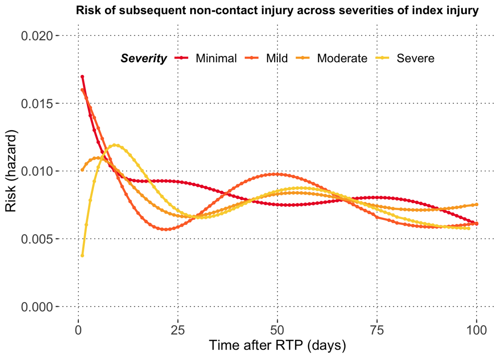

```r
# Risk trajectory across severities
Haz_seve <- filter(Haz_all_seve, Severity != "Overall")
Haz_seve$Severity <- factor(Haz_seve$Severity, levels = c("Minimal", "Mild", "Moderate", "Severe"))
f2 <- ggplot(Haz_seve, aes(x=time, y=Haz_slope, color = Severity)) + geom_point(size=1) + geom_line(size=1) + xlab("Time after RTP (days)") + ylab("Risk (hazard)") + labs(title = "Risk of subsequent non-contact injury across severities of index injury") + xlim(0, 100) + ylim(0, 0.02) + theme(plot.title = element_text(face="bold", hjust= .5, size =12), legend.position = c(.5, .88), legend.background = element_rect(fill = "transparent"), legend.key = element_rect(fill = "transparent"), legend.title = element_text(face="bold.italic", size=12), legend.text = element_text(size = 12), panel.background = element_rect(fill = "white"), panel.grid.major = element_line(color = "gray10", size = .3, linetype = "dotted"), axis.text = element_text(size = 13), axis.title = element_text(size = 14)) + scale_color_tableau(palette="Jewel Bright") + guides(color = guide_legend(direction = "horizontal"))
show(f2)
```

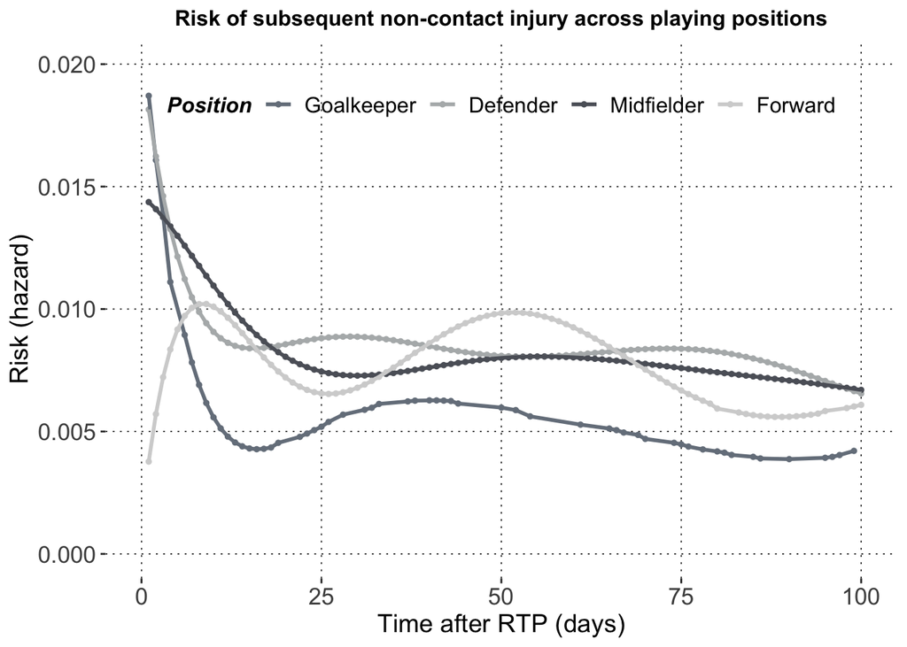

```r
# Risk trajectory across playing positions
Haz_pos <- filter(Haz_all_pos, Position != "Overall")
Haz_pos$Position <- factor(Haz_pos$Position, levels = c("Goalkeeper", "Defender", "Midfielder", "Forward"))
f3 <- ggplot(Haz_pos, aes(x=time, y=Haz_slope, color = Position)) + geom_point(size=1) + geom_line(size=1) + xlab("Time after RTP (days)") + ylab("Risk (hazard)") + labs(title = "Risk of subsequent non-contact injury across playing positions") + xlim(0, 100) + ylim(0, 0.02) + theme(plot.title = element_text(face="bold", hjust= .5, size = 12), legend.position = c(.5, .88), legend.background = element_rect(fill = "transparent"), legend.key = element_rect(fill = "transparent"), legend.title = element_text(face="bold.italic", size=12), legend.text = element_text(size = 12), panel.background = element_rect(fill = "white"), panel.grid.major = element_line(color = "gray10", size = .3, linetype = "dotted"), axis.text = element_text(size = 13), axis.title = element_text(size = 14)) + scale_color_tableau(palette="Seattle Grays") + guides(color = guide_legend(direction = "horizontal"))
show(f3)
```

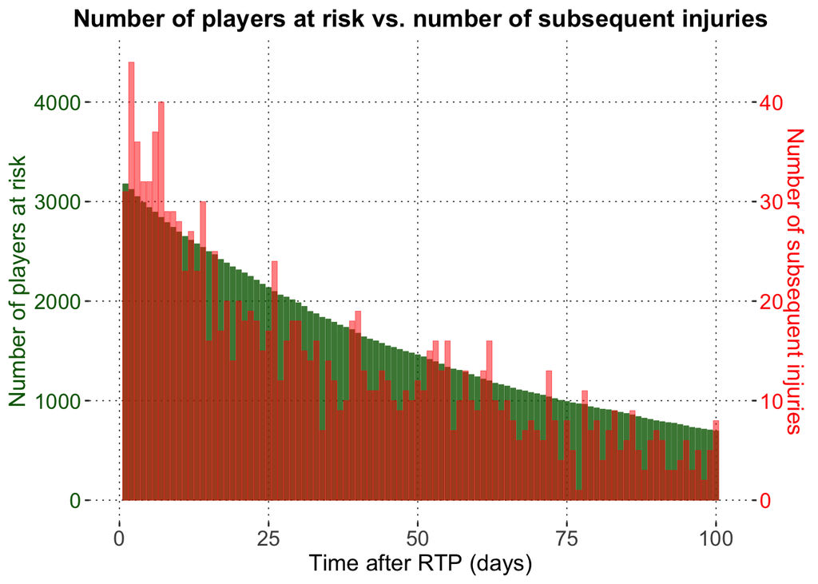

```r
# Plot number at risk together with number at risk
coeff_1=100
ggplot() + geom_bar(data=df_km_200, aes(x=time, y=n.risk), stat="identity" ,col="darkgreen", fill="darkgreen", size=0.1, alpha=.8) + geom_bar(data=df_km_200, aes(x=time, y=n.event*coeff_1), stat="identity" ,col="red", fill="red", size=0.1, alpha=.5, inherit.aes = FALSE) + xlim(0, 101) + ylim(0, 3200) + scale_y_continuous(name = "Number of players at risk", sec.axis = sec_axis(~./coeff_1, name="Number of subsequent injuries")) + xlab("Time after RTP (days)") + labs(title = "Number of players at risk vs. number of subsequent injuries") + theme(plot.title = element_text(face="bold", hjust= .5, size = 15),  panel.background = element_rect(fill = "white"), panel.grid.major = element_line(color = "gray10", size = .3, linetype = "dotted"), axis.text = element_text(size = 13), axis.title = element_text(size = 14), axis.title.y=element_text(color="darkgreen"), axis.title.y.right=element_text(color="red"), axis.text.y=element_text(color="darkgreen"), axis.text.y.right=element_text(color="red")) + guides(color = guide_legend(direction = "horizontal"))
```